# hw5

Qianhui Yang

10/28/2020

## Q1

The accuracy is 0.918, is much better than the last homework GBM result which is only about 0.5

```
## # A tibble: 6 x 3
## # Groups:   Gender [2]
##   Gender exp_group     n
##   <fct>  <chr>     <int>
## 1 Female test       1666
## 2 Female train      1667
## 3 Female validate   1667
## 4 Male   test       1666
## 5 Male   train      1667
## 6 Male   validate   1667
```

```
## Using 100 trees...
```

```
## [1] 0.9184163
```

## Q2

```
## Importance of components:
##                           PC1     PC2     PC3      PC4      PC5      PC6
## Standard deviation     46.664 23.6134 22.8884 18.88294 17.74412 17.02230
## Proportion of Variance  0.516  0.1321  0.1241  0.08449  0.07461  0.06866
## Cumulative Proportion   0.516  0.6481  0.7722  0.85673  0.93134  1.00000
```

```
## Importance of components:
##                           PC1    PC2    PC3    PC4     PC5     PC6
## Standard deviation     1.6412 1.0353 0.8695 0.7831 0.74653 0.55485
## Proportion of Variance 0.4489 0.1787 0.1260 0.1022 0.09289 0.05131
## Cumulative Proportion  0.4489 0.6276 0.7536 0.8558 0.94869 1.00000
```

```
## Importance of components:
##                           PC1    PC2    PC3     PC4     PC5     PC6       PC7
## Standard deviation     1.9211 1.0366 0.8695 0.78316 0.74661 0.55491 2.856e-16
## Proportion of Variance 0.5272 0.1535 0.1080 0.08762 0.07963 0.04399 0.000e+00
## Cumulative Proportion  0.5272 0.6807 0.7888 0.87638 0.95601 1.00000 1.000e+00
```

```
##                    PC1         PC2         PC3         PC4         PC5
## Intelligence 0.2496939 -0.60774304  0.60332047 -0.01526458  0.41765874
## Strength     0.4213660  0.16406255 -0.28736310  0.26366604  0.36562901
## Speed        0.3469851  0.28532893  0.03652766 -0.87143286  0.04583000
## Durability   0.4280366  0.20751276 -0.20342168  0.31444116  0.18853211
## Power        0.3578820  0.20627640  0.48732635  0.23723409 -0.68592601
## Combat       0.2407513 -0.65969518 -0.52266011 -0.12482382 -0.42847391
## Total        0.5200471 -0.03885949 -0.00718631  0.01085131 -0.01214364
##                       PC6        PC7
## Intelligence  0.036805516 -0.1681645
## Strength     -0.665084678 -0.2596432
## Speed         0.026818310 -0.1861172
## Durability    0.733783483 -0.2438995
## Power        -0.130336944 -0.2193658
## Combat        0.003081813 -0.1857071
## Total        -0.012372817  0.8529778
```

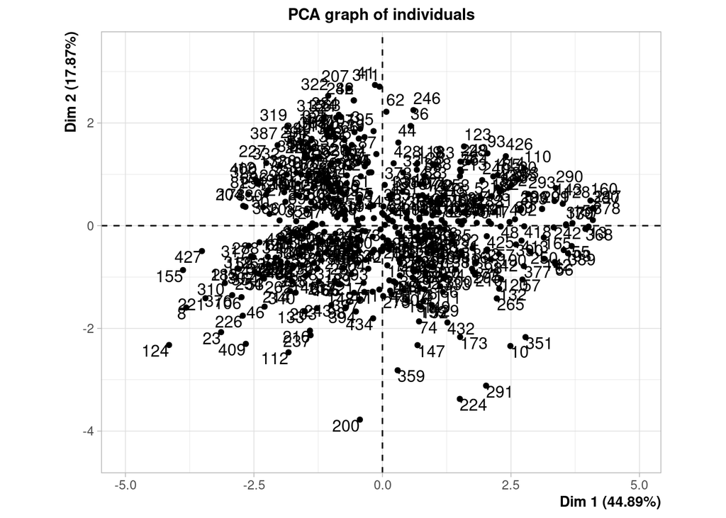

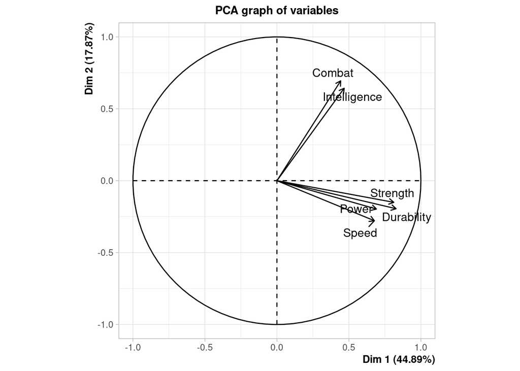

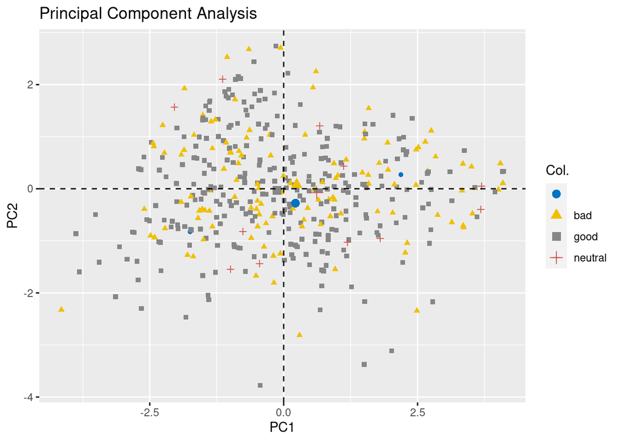

## Q3

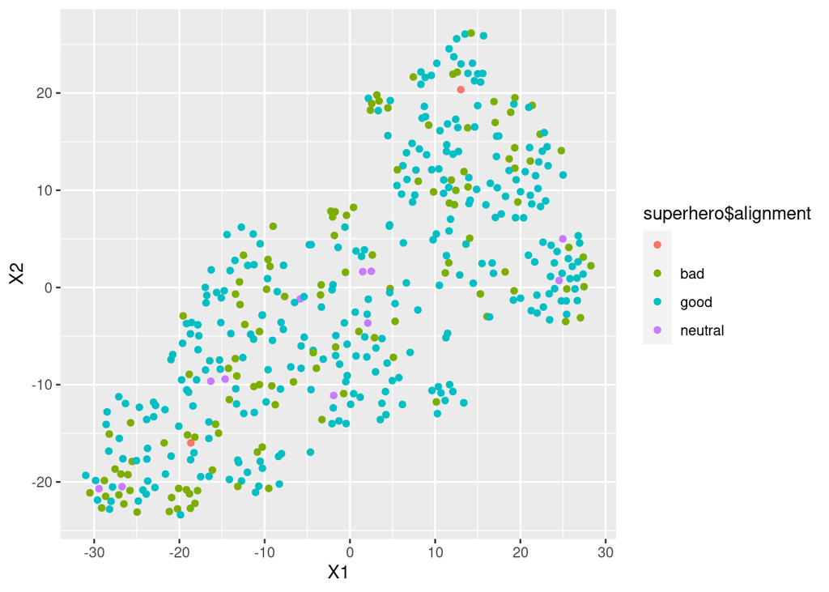

```
## List of 1
##  $ legend.position: chr "right"
##  - attr(*, "class")= chr [1:2] "theme" "gg"
##  - attr(*, "complete")= logi FALSE
##  - attr(*, "validate")= logi TRUE
```

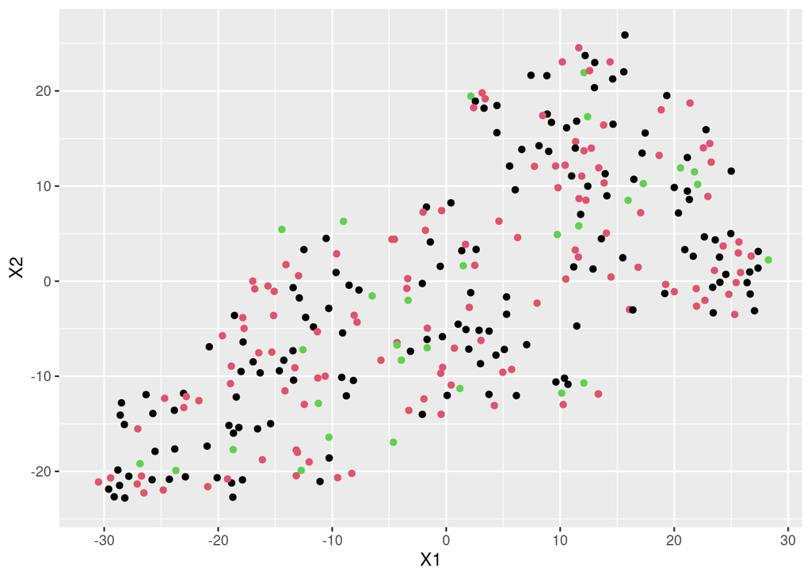

# Q4

[figure not shown]

The codes are hided in the report but can be found in the Rmarkdown code.

```
## # A tibble: 6 x 3
## # Groups:   alignment [2]
##   alignment exp_group     n
##   <chr>     <chr>     <int>
## 1 bad       test         40
## 2 bad       train        41
## 3 bad       validate     41
## 4 good      test         99
## 5 good      train       100
## 6 good      validate    100
```

```
## Stochastic Gradient Boosting
##
## 141 samples
##   6 predictor
##   2 classes: 'bad', 'good'
##
## No pre-processing
## Resampling: Cross-Validated (10 fold, repeated 10 times)
## Summary of sample sizes: 126, 127, 127, 127, 127, 127, ...
## Resampling results across tuning parameters:
##
##   interaction.depth  n.trees  Accuracy   Kappa
##   1                   50      0.6892857  0.1175362
##   1                  100      0.6783810  0.1124734
##   1                  150      0.6720000  0.1138582
##   2                   50      0.6861905  0.1429612
##   2                  100      0.6923333  0.1836428
##   2                  150      0.6893333  0.1804095
##   3                   50      0.7002381  0.1927103
##   3                  100      0.7022381  0.2151909
##   3                  150      0.6908095  0.1875441
##
## Tuning parameter 'shrinkage' was held constant at a value of 0.1
##
## Tuning parameter 'n.minobsinnode' was held constant at a value of 10
## Accuracy was used to select the optimal model using the largest value.
## The final values used for the model were n.trees = 100, interaction.depth =
##  3, shrinkage = 0.1 and n.minobsinnode = 10.
```

```
## [1] 0.6834532
```

## Q6

A conceptual question: why do we need to characterize our models using strategies like k-fold cross validation? Why can’t we just report a single number for the accuracy of our model?

No. Because it is possible that we have selected data that can’t represent our data set. It can not predict the data which is known as overfiting. To prevent this happens and make sure we can repeat the result, we use cross validation to lower the bias.

## Q7

Describe in words the process of recursive feature elimination.

First, after the initial set of feature training, the importance of each feature which is calculated by the coefficient and feature importance attribute. Then, the least important feature will be eliminated and from the current model and result as a less featured model. The process in repeated until the feature is eliminated to the numbers we want.